# Linear Regression Homework

# MVP

- Load the data into a dataframe project

```r
library(tidyverse)
library(broom)
library(modelr)
library(ggfortify)

proj_data <- read_csv("data/project_management.csv")
```

- Plot the data, taking estimated_length as the independent variable and actual_length as the dependent variable.

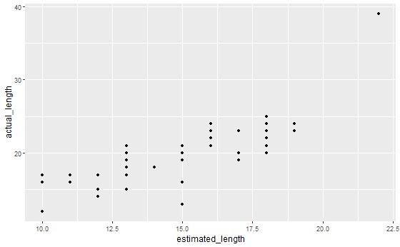

- Calculate the correlation coefficient of estimated_length and actual_length and interpret the value you obtain.

```r
  cor(proj_man_data$estimated_length, proj_man_data$actual_length)
```

```
[1] 0.8046597
```

- Perform a simple linear regression using actual length as the dependent variable, and estimated length as the independent variable. Save the model object to a variable

```r
model
```

```
Call:
lm(formula = actual_length ~ estimated_length, data = proj_man_data)

Coefficients:
     (Intercept)  estimated_length
           1.416             1.223
```

- Interpret the regression coefficient of estimated_length (ie. Slope, gradient) you obtain from the model. How do you interpret the r2 value reported by the model?

[output not shown]

```r
tidy(model)

glance(model)
```

| r.squared | adj.r.squared | sigma | statistic | p.value | df | logLik | AIC | BIC | deviance | df.residual | nobs |
| --- | --- | --- | --- | --- | --- | --- | --- | --- | --- | --- | --- |
| 0.6474772 | 0.640133 | 2.606163 | 88.16142 | 1.911284e-12 | 1 | -117.8203 | 241.6407 | 247.3767 | 326.0201 | 48 | 50 |

The r2 value reported by the model of 0.647 would show a good rate at which the model fits the data

- Is the relationship statistically significant? Remember, to assess this you need to check the p-value of the regression coefficient(or slope/gradient). But you should first check the regression diagnostic plots to see if the p-value will be reliable(don’t worry about any outlier points you see in the diagnostic plots, we’ll return to them in the extension.)

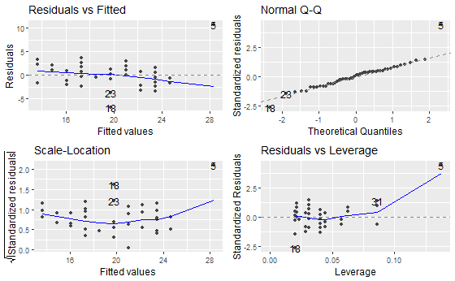

Scale-Location, plot looks fine as it is all above the x-axis with only minor fluctation

Overall these show that the p-value should be reliable